# Raport Projekt 2

autorstwa Jakub Wiśniewski & Hanna Zdulska

## Opis zbioru

W tym zbiorze danych znajdują się następujące książki z bliskiego/ dalekiego wschodu:

- Upaniszady - to starożytne teksty nauk duchowych, mówiące idei hinduizmu. Są one częścią najstarszych pism hinduizmu, Wedy, które dotyczą medytacji, filozofii i wiedzy duchowej; inne części Wedów zajmują się mantrami, błogosławieństwami, rytuałami, ceremoniami i ofiarami.
- Yoga Sutras - zbiór 196 sutr sanskryckich (aforyzmów) na temat teorii i praktyki jogi.
- Budda Sutry - początkowo były przekazywane ustnie przez mnichów, ale później zostały spisane i skomponowane jako rękopisy w różnych językach indo-aryjskich, które następnie zostały przetłumaczone na inne języki lokalne w miarę rozprzestrzeniania się buddyzmu
- Tao Te Ching - podstawowy tekst dla filozoficznego i religijnego taoizmu. Wpłynął silnie na inne szkoły chińskiej filozofii i religii, w tym konfucjanizm i buddyzm, które zostały w dużej mierze zinterpretowane poprzez użycie taoistycznych słów i pojęć, kiedy zostały pierwotnie wprowadzone do Chin.

Oraz Księgi starego testamentu

- Księga Mądrości - mowa Salomona dotycząca mądrości, bogactwa, władzy i modlitwy
- Księga Przysłów - Przysłowia to nie tylko antologia, ale „zbiór kolekcji” odnoszący się do wzoru życia, który trwał ponad tysiąc lat. Jest przykładem biblijnej tradycji mądrościowej i stawia pytania o wartości, moralne zachowanie, sens życia ludzkiego i właściwe postępowanie.
- Księga Koheleta - jest jedną z 24 ksiąg Tanach (hebrajska Biblia).
- Mądrość Syracha

## Eksploracja danych

### Struktura zbioru danych i przekształcenia

Wczytujemy dane i patrzymy na podstawowe informacje o ramce danych.

```
Number of features: 8267
Number of records: 590
Number of words in total: 60609
```

Ramka danych jest duża ma ponad 8 tysięcy unikalnych słów oraz 590 obserwacji oznaczających rozdziały, a oryginalny tekst zawierał ponad 60 tysięcy słów, to prawie tyle co "Pan Tadeusz".

A data.frame: 6 × 8267

|  | X <fct> | foolishness <int> | hath <int> | wholesome <int> | takest <int> | feelings <int> | anger <int> | vaivaswata <int> | matrix <int> | kindled <int> | ⋯ | erred <int> | thinkest <int> | modern <int> | reigned <int> | sparingly <int> | visual <int> | thoughts <int> | illumines <int> | attire <int> | explains <int> |
| --- | --- | --- | --- | --- | --- | --- | --- | --- | --- | --- | --- | --- | --- | --- | --- | --- | --- | --- | --- | --- | --- |
| 1 | Buddhism_Ch1 | 0 | 0 | 0 | 0 | 0 | 0 | 0 | 0 | 0 | ⋯ | 0 | 0 | 0 | 0 | 0 | 0 | 0 | 0 | 0 | 0 |
| 2 | Buddhism_Ch2 | 0 | 0 | 0 | 0 | 0 | 0 | 0 | 0 | 0 | ⋯ | 0 | 0 | 0 | 0 | 0 | 0 | 0 | 0 | 0 | 0 |
| 3 | Buddhism_Ch3 | 0 | 0 | 0 | 0 | 0 | 0 | 0 | 0 | 0 | ⋯ | 0 | 0 | 0 | 0 | 0 | 0 | 0 | 0 | 0 | 0 |
| 4 | Buddhism_Ch4 | 0 | 0 | 0 | 0 | 0 | 0 | 0 | 0 | 0 | ⋯ | 0 | 0 | 0 | 0 | 0 | 0 | 0 | 0 | 0 | 0 |
| 5 | Buddhism_Ch5 | 0 | 0 | 0 | 0 | 0 | 0 | 0 | 0 | 0 | ⋯ | 0 | 0 | 0 | 0 | 0 | 0 | 0 | 0 | 0 | 0 |
| 6 | Buddhism_Ch6 | 0 | 0 | 0 | 0 | 0 | 0 | 0 | 0 | 0 | ⋯ | 0 | 0 | 0 | 0 | 0 | 0 | 0 | 0 | 0 | 0 |

Patrząc na dane możemy już się domyślić, że mamy do czynienia z macierzą rzadką, gdzie dominują zera i od czasu do czasu gdy dane słowo pojawi sie w danym rozdziale pojawia się 1 (lub więcej, gdy pojawi się kilka razy).

Chcąc zobaczyć jakieś ciekawe zależności między słowami a przynależnością do danej księgi (tu w przypadku Biblii złączyliśmy 4 księgi w jedną i nazwaliśmy je "Biblia").

A data.frame: 5 × 8267

|  | book_name <fct> | foolishness <dbl> | hath <dbl> | wholesome <dbl> | takest <dbl> | feelings <dbl> | anger <dbl> | vaivaswata <dbl> | matrix <dbl> | kindled <dbl> | ⋯ | erred <dbl> | thinkest <dbl> | modern <dbl> | reigned <dbl> | sparingly <dbl> | visual <dbl> | thoughts <dbl> | illumines <dbl> | attire <dbl> | explains <dbl> |
| --- | --- | --- | --- | --- | --- | --- | --- | --- | --- | --- | --- | --- | --- | --- | --- | --- | --- | --- | --- | --- | --- |
| 1 | Buddhism | 0 | 0 | 0 | 0 | 19 | 0 | 0 | 0 | 0 | ⋯ | 0 | 0 | 0 | 0 | 0 | 0 | 9 | 0 | 0 | 0 |
| 2 | TaoTeChing | 0 | 0 | 0 | 0 | 0 | 1 | 0 | 0 | 0 | ⋯ | 0 | 0 | 0 | 0 | 0 | 0 | 0 | 0 | 0 | 0 |
| 3 | Upanishad | 0 | 0 | 0 | 0 | 0 | 3 | 1 | 0 | 1 | ⋯ | 0 | 3 | 0 | 0 | 0 | 0 | 2 | 1 | 0 | 1 |
| 4 | YogaSutra | 0 | 2 | 1 | 0 | 0 | 0 | 0 | 1 | 0 | ⋯ | 0 | 0 | 2 | 0 | 0 | 1 | 14 | 4 | 0 | 1 |
| 5 | Bible | 2 | 332 | 3 | 1 | 0 | 31 | 0 | 0 | 3 | ⋯ | 2 | 1 | 0 | 1 | 1 | 0 | 22 | 0 | 3 | 0 |

### Wizualizacja

W ramach wizualizacji najczęstszych słów postanowiliśmy stworzyć chmury słów, gdzie im częściej słowo sie pojawia, tym większe jest na wykresie. Poniżej przedstawiliśmy przykładową dla Biblii

Bible

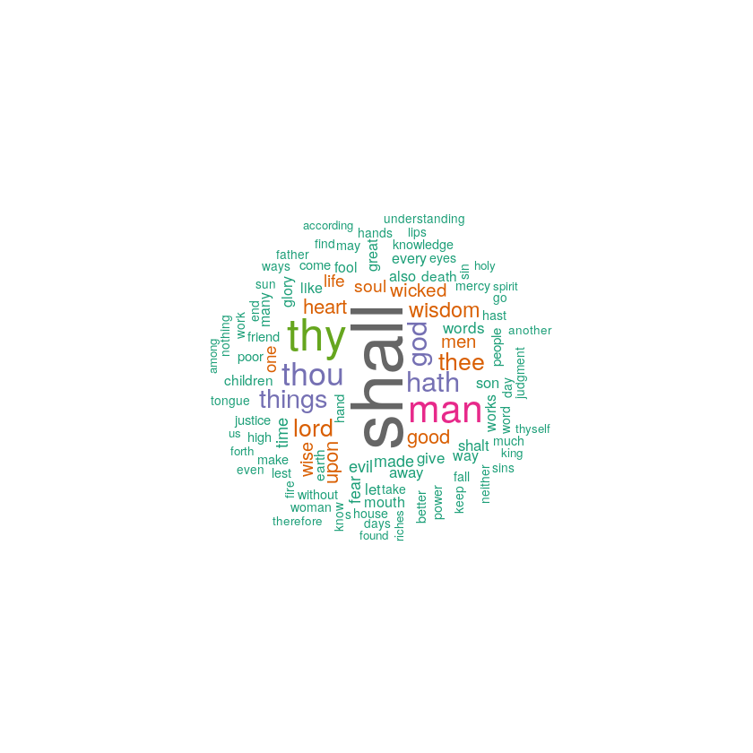

Oprócz częstości występowania słów, możemy zobaczyć jeszcze ich długość.

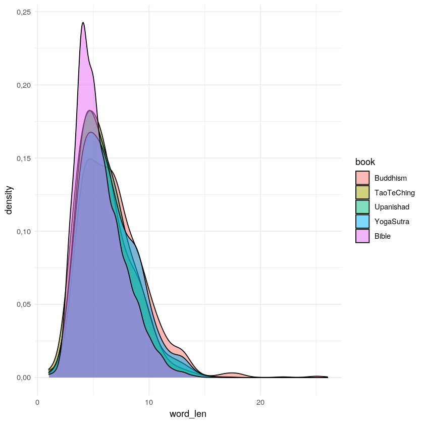

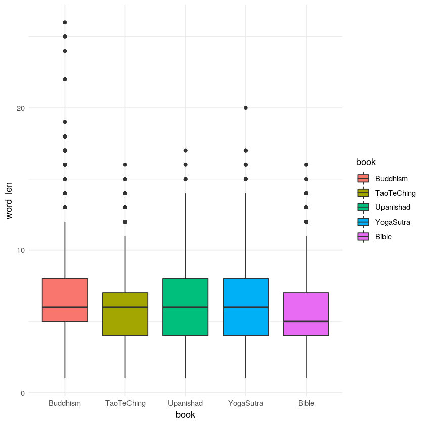

Długość słów jest podobna, Biblia ma najkrótszą medianę długości słów. Jest jednak kilka outlierów które budzą nasze wątpliwości, sprawdzimy czy to nie jest błąd.

A data.frame: 10 × 2

|  | occurrances <dbl> | names <chr> |
| --- | --- | --- |
| 1 | 16 | clingingaggregate |
| 2 | 13 | clingingaggregates |
| 3 | 8 | clingingsustenance |
| 4 | 6 | neitherpainfulnorpleasant |
| 5 | 5 | selfconsciousness |
| 6 | 3 | neitherpleasantnorpainful |
| 7 | 2 | noseconsciousness |
| 8 | 2 | incomprehensible |
| 9 | 2 | allconsciousness |
| 10 | 2 | eyeconsciousness |

Te słowa rzeczywiście występują w tekście, oto niektóre z powyższych słów wśród surowego tekstu:

```
"These are the five clinging-aggregates: form as a clinging-aggregate, feeling as a clinging-aggregate, perception as a clinging-aggregate, fabrications as a clinging-aggregate, consciousness as a clinging-aggregate... These five clinging-aggregates are rooted in desire..."The Buddha:A certain monk: "Is it the case that clinging and the five clinging-aggregates are the same thing, or are they separate?"A certain monk:The Buddha: "Clinging is neither the same thing as the five clinging-aggregates, nor are they separate. Whatever desire & passion there is with regard to the five clinging-aggregates, that is the clinging there..."

"There are three kinds of feeling: pleasant feeling, painful feeling, & neither-pleasant-nor-painful feeling... Whatever is experienced physically or mentally as pleasant & gratifying is pleasant feeling. Whatever is experienced physically or mentally as painful & hurting is painful feeling. Whatever is experienced physically or mentally as neither gratifying nor hurting is neither-pleasant-nor-painful feeling... Pleasant feeling is pleasant in remaining and painful in changing. Painful feeling is painful in remaining and pleasant in changing. Neither-pleasant-nor-painful feeling is pleasant when conjoined with knowledge and painful when devoid of knowledge."
```

--Bhuddhism

### Redukcja wymiarowości

Użyjemy `TSNE` algorytmu, który redukuje wymiarowość danych abyśmy mogli zobaczyć jak wyglądają/ mieszają się rozdziały ksiąg na przestrzeni dwuwymiarowej.

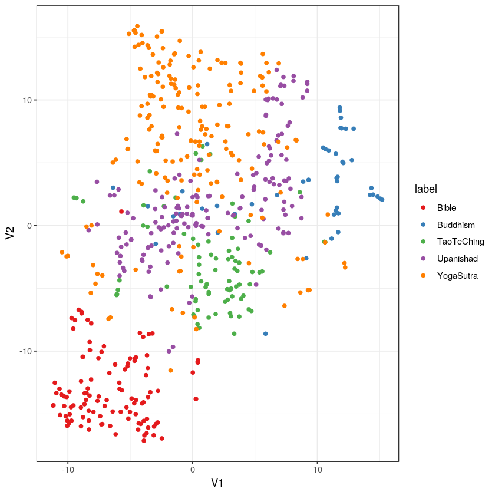

Widzimy ciekawą zależność. W czasie gdy wśród innych ksiąg nie ma wyraźnych granic Biblia wydaje się być bardzo dobrze rozróżnialna. Stąd pojawiła się nasza **Hipoteza Badawcza**

### Hipoteza: Biblię daje się dobrze sklasteryzować na tle innych ksiąg

oraz dodatkowa hipoteza badawcza:

#### Dodatkowa hipoteza: Gdy złączymy księgi biblijne w jedną księgę, metody uzyskają lepsze wyniki

### Analiza sentymentu

Słowa mogą posiadać jakieś konkretne nacechowanie, które może rozróżniać od siebie księgi. Posługując się `NRC Emotion Lexicon` rozpoznamy słowa nacechowane następującymi emocjami:

- Złość
- Strach
- Oczekiwanie
- Zaufanie
- Zaskoczenie
- Smutek
- Radość
- Obrzydzenie

Oraz to, czy nacechowanie jest pozytywne czy negatywne

[figure not shown]

Powyższe `rpivottable` posiada oddzielne księgi biblijne. Widać, że w niektórych biblijnych księgach jest więcej obrzydzenia niż strachu. Sprawdźmy na koniec jak będzie to wyglądać dla ksiąg Biblijnych oznaczonych po prostu jako Biblia.

[figure not shown]

## Inżynieria Cech

Do feature engineering spróbowaliśmy następujących podejść:

- **stop_words** - usunięcie z kolumn słów pokroju "the", "and" itp.
- entities - encja, nazwa, reprezentująca rzeczywiste obiekty (osoby, organizacje, jednostki geopolityczne etc...)
- **słownika nlp** - biblioteka, która zawiera własny słownik, wyodrębniający słowa z tekstu
- **TfidfTransformer** - skaluje wystąpienia biorąc pod uwagę wystąpienia w całym tekście, by uwzględnić wagę i częstotliwość danego słowa
- lematyzacja - sprowadzanie słów do ich podstawowego słowa, np. kotek -> kot, mierzyła -> miara
- stemming - usuwanie końcówek fleksyjnych
- usuwanie kolumn o niskiej wariancji
- redukcja wymiarów przy pomocy tsne i pca

Część metod nie polepszyła wyników, a niektóre nawet znacznie je obniżyła. Ostatecznie zdecydowaliśmy się na wykorzystanie stop-words z angielskiego słownika oraz TfidfTransformer z sklearn.

## Przetestowane modele

- KMeans
- MiniBatchKMeans
- DBSCAN
- Birch
- AgglomerativeClustering
- SpectralClustering
- GaussianMixture

  Do testowania wyników modeli użyliśmy specjanie stworzonej przez nas funkcji fast_GridSearch, która umożliwia nam przetestowanie wielu różnych modeli z różnymi parametrami.

Użyte metryki:

- homogeneity_score - mówimy, że przyporządkowanie jest homogeniczne, gdy w każdym klastrze są obserwacje tylko jednej klasy. Im bliżej `1.0` tym lepiej.
- completeness_score - mówimy że przyporządkowanie jest kompletne, gdy w wszystkie obserwacje danej klasy są przyporządkowane do tego samego klastra. Im bliżej `1.0` tym lepiej.
- v_measure_score - średnia harmoniczna z dwóch powyższych
- silhouette_score - ta miara mówi nam jak bardzo obserwacje w jednym klastrze są do siebie podobne i jak bardzo różnią się od obserwacji w innych klastrach. Wynik bliski `1.0` mówi nam, że obserwacje wewnątz klastrów są do siebie podobne i różnią się od tych z innych klastrów.

Do wyszukania najlepszych metod klasteryzacji posłórzymy się autorską funkcją grid search. Poniżej przedstawiamy wynik działania tej funkcji. Jest nią ramka danych zawierająca wyniki danej metody dla różnych parametrów.

|  | name | param1 | param2 | homogeneity_score | completeness_score | v_measure_score | silhouette_score | clusters |
| --- | --- | --- | --- | --- | --- | --- | --- | --- |
| 26 | KMeans | random | 20.0 | 0.609115 | 0.622554 | 0.615761 | -0.159806 | 5 |
| 26 | KMeans | random | 20.0 | 0.609115 | 0.622554 | 0.615761 | -0.159806 | 8 |
| 92 | Birch | 0.7000000000000001 | 10 | 0.592939 | 0.610178 | 0.601435 | -0.099444 | 8 |
| 92 | Birch | 0.7000000000000001 | 10 | 0.592939 | 0.610178 | 0.601435 | -0.099444 | 5 |
| 100 | Birch | 0.8 | 70 | 0.559585 | 0.646295 | 0.599823 | -0.162860 | 5 |
| ... | ... | ... | ... | ... | ... | ... | ... | ... |
| 30 | AgglomerativeClustering | euclidean | single | 0.007544 | 0.227242 | 0.014603 | 0.180825 | 5 |
| 32 | AgglomerativeClustering | l1 | average | 0.007544 | 0.227242 | 0.014603 | 0.311063 | 5 |
| 33 | AgglomerativeClustering | l1 | single | 0.007544 | 0.227242 | 0.014603 | 0.311063 | 5 |
| 39 | AgglomerativeClustering | manhattan | single | 0.007544 | 0.227242 | 0.014603 | 0.311063 | 5 |
| 33 | AgglomerativeClustering | l1 | single | 0.007544 | 0.227242 | 0.014603 | 0.311063 | 8 |

214 rows × 8 columns

## Biblia czy księgi?

Na początku projektu postawiliśmny hipotezę, iż łączenie ksiąg bilblijnych w jedną klasę 'Biblia' sprawi, iż modele będą osiągały lepsze wyniki. Mając wytrenowane modele dla obu wariantów możemy porównać te wyniki i jasno potwierdzić lub obalić hipotezę.

Spójrzmy jednak najpierw na dobrze nam znany łokieć oraz silhouette_score dla najbardziej trywialnego algorytmu - KMeans:

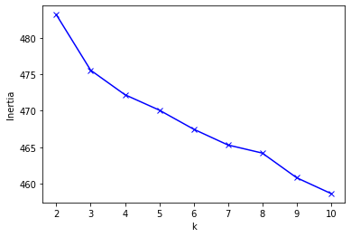

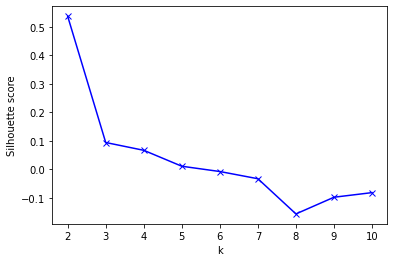

Porównajmy teraz wyniki z naszych modeli:

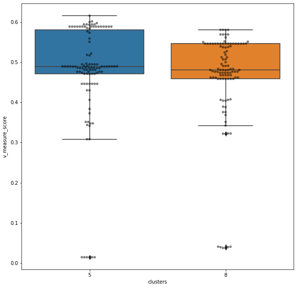

Jak widać, boxplot wyników dla ośmiu klastrów jest znaczenie bardziej zwięzły niż dla pięciu, a lepsze wyniki można osiągnąć w przypadku pięciu klastów, co potwierdza nasze domysły.

## Wnioski ze strojenia hiperparametrów - korelacja metryk

Dla wynikowej ramki danych zwróconej przez autorską funkcję grid search można zauważyć pewne korelacje między metrykami.

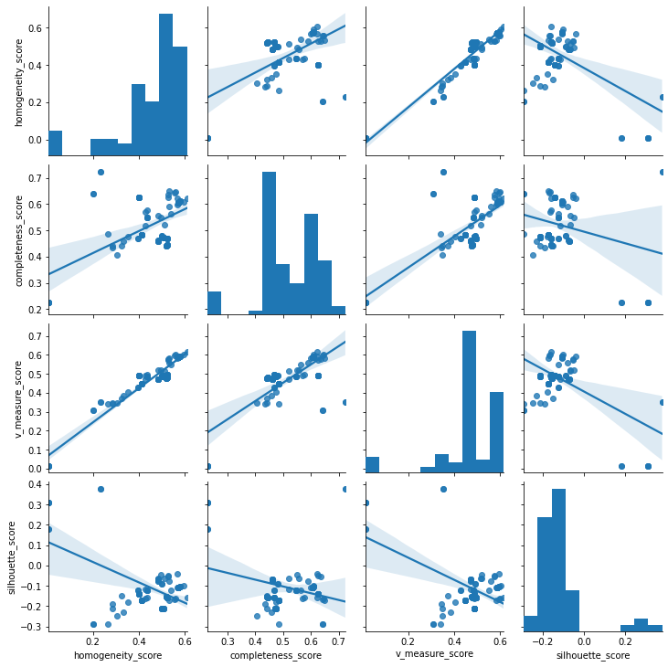

|  | homogeneity_score | completeness_score | v_measure_score | silhouette_score |
| --- | --- | --- | --- | --- |
| homogeneity_score | 1.000000 | 0.570300 | 0.962013 | -0.557255 |
| completeness_score | 0.570300 | 1.000000 | 0.756515 | -0.271697 |
| v_measure_score | 0.962013 | 0.756515 | 1.000000 | -0.567048 |
| silhouette_score | -0.557255 | -0.271697 | -0.567048 | 1.000000 |

Można tu zauważyć pewną niepokojącą zależność - silhouette_score będące odwrotnie proporcjonalne do v_measure_score. Warto zaznaczyć, iż v_measure_score jest miarą tego, jak dobrze algorytm oznaczył labels w porównaniu do prawdziwych, natomiast silhouette_score jest miarą określającą jak dobrze punkt pasuje do klastra. Ujemna korelacja sugeruje, że dobre dopasowanie do klastrów i poprawne labels **wzajemnie się wykluczają**. Najbardziej skorelowana (pozytywnie) z innymi jest metryka v_measure_score – dlatego będziemy jej używać

## Najlepszy model i wizualizacja wyniku.

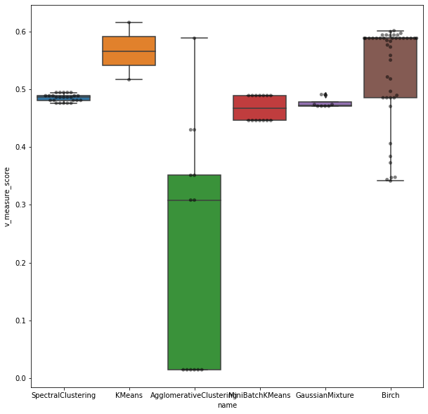

Dla porównania klasyfikacji spójrzmy poniższe wykresy.

[figure not shown]

Okazuje się że Birch zaklasteryzował Biblię w **100% poprawnie**, a w tym klastrze nie ma ani jednego innego rozdziału. Tym samym nasza **Hipoteza badawcza została potwierdzona**.

# Wnioski

- Najlepszymi modelami okazał się Birch i KMeans
- Hipoteza badawncza, iże Biblię można dobrze sklasteryzować na tle pozostałych ksiąg została potwierdzona
- Druga hipoteza, iż połączenie wszystkich księg Bibli i oznaczenie jej jako jednej klasy będzie wspomagało modele również okazała się prawdziwa - po tuningu modeli najlepszy wyniki osiągnięte zostały do 5 klas.
- NLP jest rozległą i skomplikowaną dziedziną, której nie sposób "ot tak" zaimplementować. Trzeba przyłożyć do niej dużo uwagi i wiedzy, by móc w niej działać. By poprawnie rozdzielić pozostałe księgi trzeba by poświęcić na to znacznie więcej pracy i czasu.

# Bilbiografia

- Dokumentacja sklearn - https://scikit-learn.org/stable/
- Natural Language Processing with Python by Edward Loper, Ewan Klein, and Steven Bird, 2009

# Oświadczenie o samodzielności

Oświadczamy, że niniejsza praca stanowiąca podstawę do uznania osiągnięcia efektów uczenia się z przedmiotu Wstęp do Uczenia Maszynowego, została wykonana przez nas samodzielnie.

Hanna Zdulska, Jakub Wiśniewski